# Bivariate Analysis

## Ucitavanje potrebnih biblioteka

```r
install.packages("rstatix")
```

```
Error in install.packages : Updating loaded packages
```

```r
library(tidyverse)
library(car)
library(FSA)
library(rstatix)
```

## Kategorijske prema ciljnoj varijabli

### Distribucija varijable Premium Amount u odnosu na Gender

Osnovni opis varijabli

```r
df_summary_feature <- train %>%
  group_by(Gender) %>%
  summarise(
    Count = n(),
    Mean_Premium_Amount = mean(Premium.Amount, na.rm = TRUE),
    Median_Premium_Amount = median(Premium.Amount, na.rm = TRUE),
    Std_Premium_Amount = sd(Premium.Amount, na.rm = TRUE),
    IQR_Premium_Amount = IQR(Premium.Amount, na.rm = TRUE)
  ) %>%
  arrange(desc(Mean_Premium_Amount))

print(df_summary_feature)
```

| Gender | Count | Mean_Premium_Amount | Median_Premium_Amount | Std_Premium_Amount | IQR_Premium_Amount |
| --- | --- | --- | --- | --- | --- |
| Male | 602571 | 1102.683 | 872 | 865.2152 | 998 |
| Female | 597429 | 1102.405 | 872 | 864.7813 | 993 |

Graficka reprezentacija varijabli

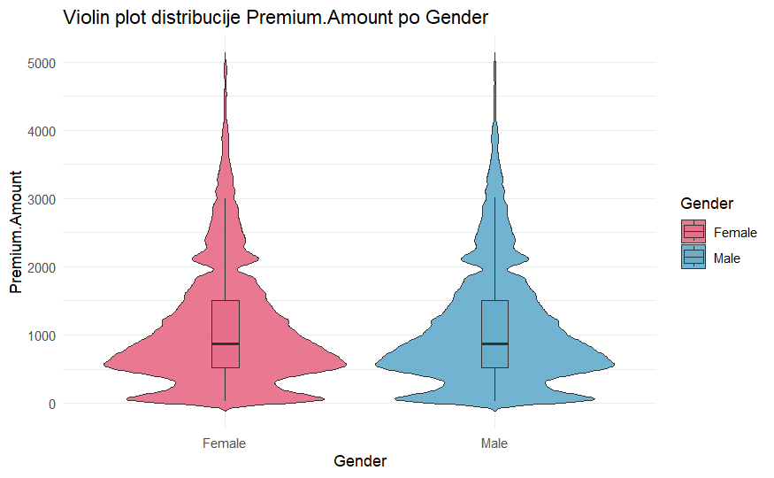

```r
ggplot(train, aes(x = Gender, y = Premium.Amount, fill = Gender)) +
  geom_violin(trim = FALSE, alpha = 0.8) +
  geom_boxplot(width = 0.1, outlier.shape = NA, alpha = 0.3) +
  scale_fill_manual(values = c("Female" = "#e45775", "Male" = "#4ea0c4")) +
  labs(title = "Violin plot distribucije Premium.Amount po Gender", x = "Gender", y = "Premium.Amount") +
  theme_minimal()
```

Statisticka analiza zavisnosti varijabli

```r
set.seed(123)
categories <- unique(train$Gender)
categories <- categories[!is.na(categories)]

shapiro_boot <- function(cat) {
  values <- na.omit(train$Premium.Amount[train$Gender == cat])

  if (length(values) > 3) {
    p_values <- replicate(500, shapiro.test(sample(values, min(3000, length(values))))$p.value)
    p_mean <- mean(p_values)

    if (p_mean > 0.05) {
      sprintf("Varijabla Premium.Amount po %s kategoriji ima normalnu raspodelu.", as.character(cat))
    } else {
      sprintf("Varijabla Premium.Amount po %s kategoriji nema normalnu raspodelu.", as.character(cat))
    }
  }
  else {
    sprintf("Varijabla Premium.Amount po %s kategoriji ima manje od 3 observacije.", as.character(cat))
  }
}

lapply(categories, shapiro_boot)
```

```
[[1]]
[1] "Varijabla Premium.Amount po Female kategoriji nema normalnu raspodelu."

[[2]]
[1] "Varijabla Premium.Amount po Male kategoriji nema normalnu raspodelu."
```

Mann-Withney test radi statisticke provere distribucije po kategorijama

```r
p_value <- wilcox.test(Premium.Amount ~ Gender, data = train)$p.value

if (p_value > 0.05) {
  print("Nema statisticke razlike izmedju distribucija Premium.Amount po kategorijama Gender atributa.")
} else {
  print("Postoji statisticka razlika izmedju distribucija Premium.Amount po kategorijama Gender atributa.")
}
```

```
[1] "Nema statisticke razlike izmedju distribucija Premium.Amount po kategorijama Gender atributa."
```

### Distribucija varijable Premium Amount u odnosu na Marital.Status

Osnovni opis varijabli

```r
df_summary_feature <- train %>%
  group_by(Marital.Status) %>%
  summarise(
    Count = n(),
    Mean_Premium_Amount = mean(Premium.Amount, na.rm = TRUE),
    Median_Premium_Amount = median(Premium.Amount, na.rm = TRUE),
    Std_Premium_Amount = sd(Premium.Amount, na.rm = TRUE),
    IQR_Premium_Amount = IQR(Premium.Amount, na.rm = TRUE)
  ) %>%
  arrange(desc(Mean_Premium_Amount))

print(df_summary_feature)
```

| Marital.Status | Count | Mean_Premium_Amount | Median_Premium_Amount | Std_Premium_Amount | IQR_Premium_Amount |
| --- | --- | --- | --- | --- | --- |
| NA | 18529 | 1217.871 | 1001 | 904.2862 | 1088 |
| Single | 395391 | 1101.736 | 872 | 864.2915 | 991 |
| Divorced | 391764 | 1100.625 | 870 | 865.5313 | 994 |
| Married | 394316 | 1099.844 | 870 | 862.9236 | 992 |

Graficka reprezentacija varijabli

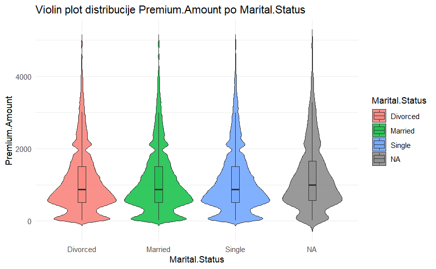

```r
ggplot(train, aes(x = Marital.Status, y = Premium.Amount, fill = Marital.Status)) +
  geom_violin(trim = FALSE, alpha = 0.8) +
  geom_boxplot(width = 0.1, outlier.shape = NA, alpha = 0.3) +
  labs(title = "Violin plot distribucije Premium.Amount po Marital.Status", x = "Marital.Status", y = "Premium.Amount") +
  theme_minimal()
```

Statisticka analiza zavisnosti varijabli

```r
set.seed(123)
categories <- unique(train$Marital.Status)
categories <- categories[!is.na(categories)]

shapiro_boot <- function(cat) {
  values <- na.omit(train$Premium.Amount[train$Marital.Status == cat])

  if (length(values) > 3) {
    p_values <- replicate(500, shapiro.test(sample(values, min(3000, length(values))))$p.value)
    p_mean <- mean(p_values)

    if (p_mean > 0.05) {
      sprintf("Varijabla Premium.Amount po %s kategoriji ima normalnu raspodelu.", as.character(cat))
    } else {
      sprintf("Varijabla Premium.Amount po %s kategoriji nema normalnu raspodelu.", as.character(cat))
    }
  }
  else {
    sprintf("Varijabla Premium.Amount po %s kategoriji ima manje od 3 observacije.", as.character(cat))
  }
}

lapply(categories, shapiro_boot)
```

```
[[1]]
[1] "Varijabla Premium.Amount po Married kategoriji nema normalnu raspodelu."

[[2]]
[1] "Varijabla Premium.Amount po Divorced kategoriji nema normalnu raspodelu."

[[3]]
[1] "Varijabla Premium.Amount po Single kategoriji nema normalnu raspodelu."
```

Kruskal-Wallis test radi statisticke provere distribucije po kategorijama

```r
p_value <- kruskal_test(Premium.Amount ~ Marital.Status, data = train)$p

if (p_value > 0.05) {
  print("Nema statisticke razlike izmedju distribucija Premium.Amount po kategorijama Marital.Status atributa.")
} else {
  print("Postoji statisticka razlika izmedju distribucija Premium.Amount po kategorijama Marital.Status atributa.")
}
```

```
[1] "Nema statisticke razlike izmedju distribucija Premium.Amount po kategorijama Marital.Status atributa."
```

### Distribucija varijable Premium Amount u odnosu na Education.Level

Osnovni opis varijabli

```r
df_summary_feature <- train %>%
  group_by(Education.Level) %>%
  summarise(
    Count = n(),
    Mean_Premium_Amount = mean(Premium.Amount, na.rm = TRUE),
    Median_Premium_Amount = median(Premium.Amount, na.rm = TRUE),
    Std_Premium_Amount = sd(Premium.Amount, na.rm = TRUE),
    IQR_Premium_Amount = IQR(Premium.Amount, na.rm = TRUE)
  ) %>%
  arrange(desc(Mean_Premium_Amount))

print(df_summary_feature)
```

| Education.Level | Count | Mean_Premium_Amount | Median_Premium_Amount | Std_Premium_Amount | IQR_Premium_Amount |
| --- | --- | --- | --- | --- | --- |
| High School | 289441 | 1104.787 | 876 | 865.9515 | 999 |
| Bachelor's | 303234 | 1102.698 | 873 | 864.8663 | 995 |
| Master's | 303818 | 1102.114 | 871 | 866.2353 | 999 |
| PhD | 303507 | 1100.684 | 869 | 862.9807 | 988 |

Graficka reprezentacija varijabli

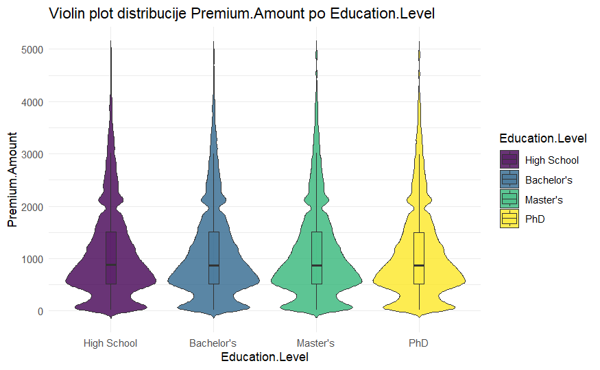

```r
ggplot(train, aes(x = Education.Level, y = Premium.Amount, fill = Education.Level)) +
  geom_violin(trim = FALSE, alpha = 0.8) +
  geom_boxplot(width = 0.1, outlier.shape = NA, alpha = 0.3) +
  labs(title = "Violin plot distribucije Premium.Amount po Education.Level", x = "Education.Level", y = "Premium.Amount") +
  theme_minimal()
```

Statisticka analiza zavisnosti varijabli

```r
set.seed(123)
categories <- unique(train$Education.Level)
categories <- categories[!is.na(categories)]

shapiro_boot <- function(cat) {
  values <- na.omit(train$Premium.Amount[train$Education.Level == cat])

  if (length(values) > 3) {
    p_values <- replicate(500, shapiro.test(sample(values, min(3000, length(values))))$p.value)
    p_mean <- mean(p_values)

    if (p_mean > 0.05) {
      sprintf("Varijabla Premium.Amount po %s kategoriji ima normalnu raspodelu.", as.character(cat))
    } else {
      sprintf("Varijabla Premium.Amount po %s kategoriji nema normalnu raspodelu.", as.character(cat))
    }
  }
  else {
    sprintf("Varijabla Premium.Amount po %s kategoriji ima manje od 3 observacije.", as.character(cat))
  }
}

lapply(categories, shapiro_boot)
```

```
[[1]]
[1] "Varijabla Premium.Amount po Bachelor's kategoriji nema normalnu raspodelu."

[[2]]
[1] "Varijabla Premium.Amount po Master's kategoriji nema normalnu raspodelu."

[[3]]
[1] "Varijabla Premium.Amount po High School kategoriji nema normalnu raspodelu."

[[4]]
[1] "Varijabla Premium.Amount po PhD kategoriji nema normalnu raspodelu."
```

Kruskal-Wallis test radi statisticke provere distribucije po kategorijama

```r
p_value <- kruskal_test(Premium.Amount~Education.Level,data=train)$p

if (p_value > 0.05) {
  print("Nema statisticke razlike izmedju distribucija Premium.Amount po kategorijama Education.Level atributa.")
} else {
  print("Postoji statisticka razlika izmedju distribucija Premium.Amount po kategorijama Education.Level atributa.")
}
```

```
[1] "Nema statisticke razlike izmedju distribucija Premium.Amount po kategorijama Education.Level atributa."
```

### Distribucija varijable Premium Amount u odnosu na Occupation

Osnovni opis varijabli

```r
df_summary_feature <- train %>%
  group_by(Occupation) %>%
  summarise(
    Count = n(),
    Mean_Premium_Amount = mean(Premium.Amount, na.rm = TRUE),
    Median_Premium_Amount = median(Premium.Amount, na.rm = TRUE),
    Std_Premium_Amount = sd(Premium.Amount, na.rm = TRUE),
    IQR_Premium_Amount = IQR(Premium.Amount, na.rm = TRUE)
  ) %>%
  arrange(desc(Mean_Premium_Amount))

print(df_summary_feature)
```

| Occupation | Count | Mean_Premium_Amount | Median_Premium_Amount | Std_Premium_Amount | IQR_Premium_Amount |
| --- | --- | --- | --- | --- | --- |
| Employed | 282750 | 1107.401 | 881 | 863.0211 | 997 |
| Self-Employed | 282645 | 1106.609 | 874 | 870.2483 | 1005 |
| Unemployed | 276530 | 1105.369 | 874 | 868.4641 | 997 |
| NA | 358075 | 1093.321 | 861 | 859.6371 | 983 |

Graficka reprezentacija varijabli

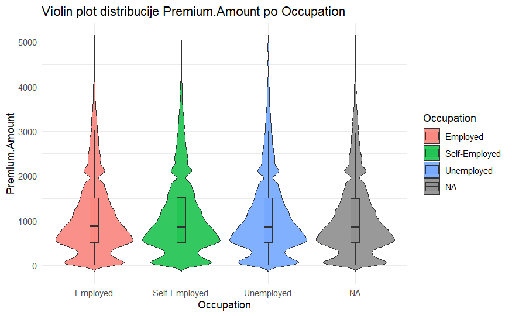

```r
ggplot(train, aes(x = Occupation, y = Premium.Amount, fill = Occupation)) +
  geom_violin(trim = FALSE, alpha = 0.8) +
  geom_boxplot(width = 0.1, outlier.shape = NA, alpha = 0.3) +
  labs(title = "Violin plot distribucije Premium.Amount po Occupation", x = "Occupation", y = "Premium.Amount") +
  theme_minimal()
```

Statisticka analiza zavisnosti varijabli

```r
set.seed(123)
categories <- unique(train$Occupation)
categories <- categories[!is.na(categories)]

shapiro_boot <- function(cat) {
  values <- na.omit(train$Premium.Amount[train$Occupation == cat])

  if (length(values) > 3) {
    p_values <- replicate(500, shapiro.test(sample(values, min(3000, length(values))))$p.value)
    p_mean <- mean(p_values)

    if (p_mean > 0.05) {
      sprintf("Varijabla Premium.Amount po %s kategoriji ima normalnu raspodelu.", as.character(cat))
    } else {
      sprintf("Varijabla Premium.Amount po %s kategoriji nema normalnu raspodelu.", as.character(cat))
    }
  }
  else {
    sprintf("Varijabla Premium.Amount po %s kategoriji ima manje od 3 observacije.", as.character(cat))
  }
}

lapply(categories, shapiro_boot)
```

```
[[1]]
[1] "Varijabla Premium.Amount po Self-Employed kategoriji nema normalnu raspodelu."

[[2]]
[1] "Varijabla Premium.Amount po Employed kategoriji nema normalnu raspodelu."

[[3]]
[1] "Varijabla Premium.Amount po Unemployed kategoriji nema normalnu raspodelu."
```

Kruskal-Wallis test radi statisticke provere distribucije po kategorijama

```r
p_value <- kruskal_test(Premium.Amount~Occupation,data=train)$p

if (p_value > 0.05) {
  print("Nema statisticke razlike izmedju distribucija Premium.Amount po kategorijama Occupation atributa.")
} else {
  print("Postoji statisticka razlika izmedju distribucija Premium.Amount po kategorijama Occupation atributa.")
}
```

```
[1] "Postoji statisticka razlika izmedju distribucija Premium.Amount po kategorijama Occupation atributa."
```

Racunamo efekat Kruskal-Wallis testa kako bismo proverili:

```r
kruskal_effsize(Premium.Amount~Occupation,data=train)$effsize
```

[output not shown]

Iako je Kruskal-Wallis test ukazao na to da postoji statisticki znacajna razlika u raspodeli Premium.Amount varijable u odnosu na nivoe Occupation varijable, analizom vrednosti efekta, kao i uporedjivanjem medijana i IQR-a, utvrdjujemo da je ova razlika minimalna i prakticno neprimenljiva.

### Distribucija varijable Premium Amount u odnosu na Location

Osnovni opis varijabli

```r
df_summary_feature <- train %>%
  group_by(Location) %>%
  summarise(
    Count = n(),
    Mean_Premium_Amount = mean(Premium.Amount, na.rm = TRUE),
    Median_Premium_Amount = median(Premium.Amount, na.rm = TRUE),
    Std_Premium_Amount = sd(Premium.Amount, na.rm = TRUE),
    IQR_Premium_Amount = IQR(Premium.Amount, na.rm = TRUE)
  ) %>%
  arrange(desc(Mean_Premium_Amount))

print(df_summary_feature)
```

| Location | Count | Mean_Premium_Amount | Median_Premium_Amount | Std_Premium_Amount | IQR_Premium_Amount |
| --- | --- | --- | --- | --- | --- |
| Urban | 397511 | 1103.715 | 874 | 864.6831 | 994 |
| Suburban | 401542 | 1102.462 | 871 | 865.2511 | 996 |
| Rural | 400947 | 1101.468 | 871 | 865.0599 | 994 |

Graficka reprezentacija varijabli

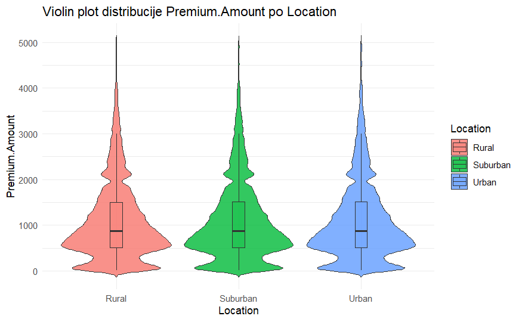

```r
ggplot(train, aes(x = Location, y = Premium.Amount, fill = Location)) +
  geom_violin(trim = FALSE, alpha = 0.8) +
  geom_boxplot(width = 0.1, outlier.shape = NA, alpha = 0.3) +
  labs(title = "Violin plot distribucije Premium.Amount po Location", x = "Location", y = "Premium.Amount") +
  theme_minimal()
```

Statisticka analiza zavisnosti varijabli

```r
set.seed(123)
categories <- unique(train$Location)
categories <- categories[!is.na(categories)]

shapiro_boot <- function(cat) {
  values <- na.omit(train$Premium.Amount[train$Location == cat])

  if (length(values) > 3) {
    p_values <- replicate(500, shapiro.test(sample(values, min(3000, length(values))))$p.value)
    p_mean <- mean(p_values)

    if (p_mean > 0.05) {
      sprintf("Varijabla Premium.Amount po %s kategoriji ima normalnu raspodelu.", as.character(cat))
    } else {
      sprintf("Varijabla Premium.Amount po %s kategoriji nema normalnu raspodelu.", as.character(cat))
    }
  }
  else {
    sprintf("Varijabla Premium.Amount po %s kategoriji ima manje od 3 observacije.", as.character(cat))
  }
}

lapply(categories, shapiro_boot)
```

```
[[1]]
[1] "Varijabla Premium.Amount po Urban kategoriji nema normalnu raspodelu."

[[2]]
[1] "Varijabla Premium.Amount po Rural kategoriji nema normalnu raspodelu."

[[3]]
[1] "Varijabla Premium.Amount po Suburban kategoriji nema normalnu raspodelu."
```

Kruskal-Wallis test radi statisticke provere distribucije po kategorijama

```r
p_value <- kruskal_test(Premium.Amount ~ Location, data = train)$p

if (p_value > 0.05) {
  print("Nema statisticke razlike izmedju distribucija Premium.Amount po kategorijama Location atributa.")
} else {
  print("Postoji statisticka razlika izmedju distribucija Premium.Amount po kategorijama Location atributa.")
}
```

```
[1] "Nema statisticke razlike izmedju distribucija Premium.Amount po kategorijama Location atributa."
```

### Distribucija varijable Premium Amount u odnosu na Policy.Type

Osnovni opis varijabli

```r
df_summary_feature <- train %>%
  group_by(Policy.Type) %>%
  summarise(
    Count = n(),
    Mean_Premium_Amount = mean(Premium.Amount, na.rm = TRUE),
    Median_Premium_Amount = median(Premium.Amount, na.rm = TRUE),
    Std_Premium_Amount = sd(Premium.Amount, na.rm = TRUE),
    IQR_Premium_Amount = IQR(Premium.Amount, na.rm = TRUE)
  ) %>%
  arrange(desc(Mean_Premium_Amount))

print(df_summary_feature)
```

| Policy.Type | Count | Mean_Premium_Amount | Median_Premium_Amount | Std_Premium_Amount | IQR_Premium_Amount |
| --- | --- | --- | --- | --- | --- |
| Basic | 398554 | 1103.452 | 874 | 864.8613 | 999 |
| Comprehensive | 399600 | 1102.611 | 873 | 864.8730 | 993 |
| Premium | 401846 | 1101.579 | 870 | 865.2615 | 994 |

Graficka reprezentacija varijabli

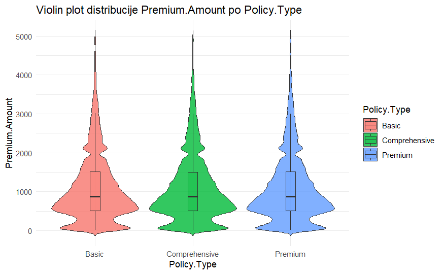

```r
ggplot(train, aes(x = Policy.Type, y = Premium.Amount, fill = Policy.Type)) +
  geom_violin(trim = FALSE, alpha = 0.8) +
  geom_boxplot(width = 0.1, outlier.shape = NA, alpha = 0.3) +
  labs(title = "Violin plot distribucije Premium.Amount po Policy.Type", x = "Policy.Type", y = "Premium.Amount") +
  theme_minimal()
```

Statisticka analiza zavisnosti varijabli

```r
set.seed(123)
categories <- unique(train$Policy.Type)
categories <- categories[!is.na(categories)]

shapiro_boot <- function(cat) {
  values <- na.omit(train$Premium.Amount[train$Policy.Type == cat])

  if (length(values) > 3) {
    p_values <- replicate(500, shapiro.test(sample(values, min(3000, length(values))))$p.value)
    p_mean <- mean(p_values)

    if (p_mean > 0.05) {
      sprintf("Varijabla Premium.Amount po %s kategoriji ima normalnu raspodelu.", as.character(cat))
    } else {
      sprintf("Varijabla Premium.Amount po %s kategoriji nema normalnu raspodelu.", as.character(cat))
    }
  }
  else {
    sprintf("Varijabla Premium.Amount po %s kategoriji ima manje od 3 observacije.", as.character(cat))
  }
}

lapply(categories, shapiro_boot)
```

```
[[1]]
[1] "Varijabla Premium.Amount po Premium kategoriji nema normalnu raspodelu."

[[2]]
[1] "Varijabla Premium.Amount po Comprehensive kategoriji nema normalnu raspodelu."

[[3]]
[1] "Varijabla Premium.Amount po Basic kategoriji nema normalnu raspodelu."
```

Kruskal-Wallis test radi statisticke provere distribucije po kategorijama

```r
p_value <- kruskal_test(Premium.Amount ~ Policy.Type, data = train)$p

if (p_value > 0.05) {
  print("Nema statisticke razlike izmedju distribucija Premium.Amount po kategorijama Policy.Type atributa.")
} else {
  print("Postoji statisticka razlika izmedju distribucija Premium.Amount po kategorijama Policy.Type atributa.")
}
```

```
[1] "Nema statisticke razlike izmedju distribucija Premium.Amount po kategorijama Policy.Type atributa."
```

### Distribucija varijable Premium Amount u odnosu na Customer.Feedback

Osnovni opis varijabli

```r
df_summary_feature <- train %>%
  group_by(Customer.Feedback) %>%
  summarise(
    Count = n(),
    Mean_Premium_Amount = mean(Premium.Amount, na.rm = TRUE),
    Median_Premium_Amount = median(Premium.Amount, na.rm = TRUE),
    Std_Premium_Amount = sd(Premium.Amount, na.rm = TRUE),
    IQR_Premium_Amount = IQR(Premium.Amount, na.rm = TRUE)
  ) %>%
  arrange(desc(Mean_Premium_Amount))

print(df_summary_feature)
```

| Customer.Feedback | Count | Mean_Premium_Amount | Median_Premium_Amount | Std_Premium_Amount | IQR_Premium_Amount |
| --- | --- | --- | --- | --- | --- |
| NA | 77824 | 1189.620 | 956 | 883.8666 | 1060 |
| Poor | 375518 | 1098.893 | 868 | 865.1830 | 994 |
| Good | 368753 | 1096.284 | 861 | 863.2093 | 985 |
| Average | 377905 | 1094.351 | 861 | 861.6583 | 986 |

Graficka reprezentacija varijabli

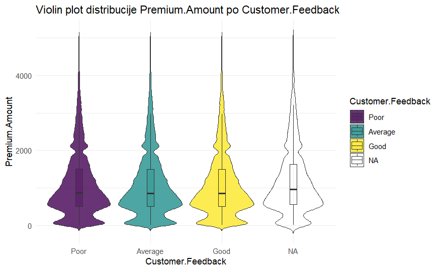

```r
ggplot(train, aes(x = Customer.Feedback, y = Premium.Amount, fill = Customer.Feedback)) +
  geom_violin(trim = FALSE, alpha = 0.8) +
  geom_boxplot(width = 0.1, outlier.shape = NA, alpha = 0.3) +
  labs(title = "Violin plot distribucije Premium.Amount po Customer.Feedback", x = "Customer.Feedback", y = "Premium.Amount") +
  theme_minimal()
```

Statisticka analiza zavisnosti varijabli

```r
set.seed(123)
categories <- unique(train$Customer.Feedback)
categories <- categories[!is.na(categories)]

shapiro_boot <- function(cat) {
  values <- na.omit(train$Premium.Amount[train$Customer.Feedback == cat])

  if (length(values) > 3) {
    p_values <- replicate(500, shapiro.test(sample(values, min(3000, length(values))))$p.value)
    p_mean <- mean(p_values)

    if (p_mean > 0.05) {
      sprintf("Varijabla Premium.Amount po %s kategoriji ima normalnu raspodelu.", as.character(cat))
    } else {
      sprintf("Varijabla Premium.Amount po %s kategoriji nema normalnu raspodelu.", as.character(cat))
    }
  }
  else {
    sprintf("Varijabla Premium.Amount po %s kategoriji ima manje od 3 observacije.", as.character(cat))
  }
}

lapply(categories, shapiro_boot)
```

```
[[1]]
[1] "Varijabla Premium.Amount po Poor kategoriji nema normalnu raspodelu."

[[2]]
[1] "Varijabla Premium.Amount po Average kategoriji nema normalnu raspodelu."

[[3]]
[1] "Varijabla Premium.Amount po Good kategoriji nema normalnu raspodelu."
```

Kruskal-Wallis test radi statisticke provere distribucije po kategorijama

```r
p_value <- kruskal_test(Premium.Amount ~ Customer.Feedback, data = train)$p

if (p_value > 0.05) {
  print("Nema statisticke razlike izmedju distribucija Premium.Amount po kategorijama Customer.Feedback atributa.")
} else {
  print("Postoji statisticka razlika izmedju distribucija Premium.Amount po kategorijama Customer.Feedback atributa.")
}
```

```
[1] "Nema statisticke razlike izmedju distribucija Premium.Amount po kategorijama Customer.Feedback atributa."
```

### Distribucija varijable Premium Amount u odnosu na Smoking.Status

Osnovni opis varijabli

```r
df_summary_feature <- train %>%
  group_by(Smoking.Status) %>%
  summarise(
    Count = n(),
    Mean_Premium_Amount = mean(Premium.Amount, na.rm = TRUE),
    Median_Premium_Amount = median(Premium.Amount, na.rm = TRUE),
    Std_Premium_Amount = sd(Premium.Amount, na.rm = TRUE),
    IQR_Premium_Amount = IQR(Premium.Amount, na.rm = TRUE)
  ) %>%
  arrange(desc(Mean_Premium_Amount))

print(df_summary_feature)
```

| Smoking.Status | Count | Mean_Premium_Amount | Median_Premium_Amount | Std_Premium_Amount | IQR_Premium_Amount |
| --- | --- | --- | --- | --- | --- |
| Yes | 601873 | 1102.685 | 872 | 864.7763 | 992 |
| No | 598127 | 1102.404 | 872 | 865.2235 | 999 |

Graficka reprezentacija varijabli

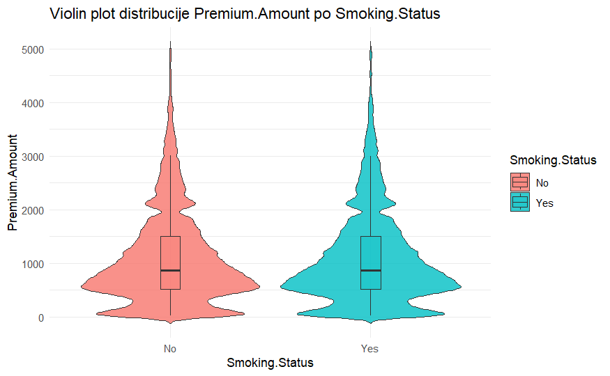

```r
ggplot(train, aes(x = Smoking.Status, y = Premium.Amount, fill = Smoking.Status)) +
  geom_violin(trim = FALSE, alpha = 0.8) +
  geom_boxplot(width = 0.1, outlier.shape = NA, alpha = 0.3) +
  labs(title = "Violin plot distribucije Premium.Amount po Smoking.Status", x = "Smoking.Status", y = "Premium.Amount") +
  theme_minimal()
```

Statisticka analiza zavisnosti varijabli

```r
set.seed(123)
categories <- unique(train$Smoking.Status)
categories <- categories[!is.na(categories)]

shapiro_boot <- function(cat) {
  values <- na.omit(train$Premium.Amount[train$Smoking.Status == cat])

  if (length(values) > 3) {
    p_values <- replicate(500, shapiro.test(sample(values, min(3000, length(values))))$p.value)
    p_mean <- mean(p_values)

    if (p_mean > 0.05) {
      sprintf("Varijabla Premium.Amount po %s kategoriji ima normalnu raspodelu.", as.character(cat))
    } else {
      sprintf("Varijabla Premium.Amount po %s kategoriji nema normalnu raspodelu.", as.character(cat))
    }
  }
  else {
    sprintf("Varijabla Premium.Amount po %s kategoriji ima manje od 3 observacije.", as.character(cat))
  }
}

lapply(categories, shapiro_boot)
```

```
[[1]]
[1] "Varijabla Premium.Amount po No kategoriji nema normalnu raspodelu."

[[2]]
[1] "Varijabla Premium.Amount po Yes kategoriji nema normalnu raspodelu."
```

Mann-Withney test radi statisticke provere distribucije po kategorijama

```r
p_value <- wilcox.test(Premium.Amount ~ Smoking.Status, data = train)$p.value

if (p_value > 0.05) {
  print("Nema statisticke razlike izmedju distribucija Premium.Amount po kategorijama Smoking.Status atributa.")
} else {
  print("Postoji statisticka razlika izmedju distribucija Premium.Amount po kategorijama Smoking.Status atributa.")
}
```

```
[1] "Nema statisticke razlike izmedju distribucija Premium.Amount po kategorijama Smoking.Status atributa."
```

### Distribucija varijable Premium Amount u odnosu na Exercise.Frequency

Osnovni opis varijabli

```r
df_summary_feature <- train %>%
  group_by(Exercise.Frequency) %>%
  summarise(
    Count = n(),
    Mean_Premium_Amount = mean(Premium.Amount, na.rm = TRUE),
    Median_Premium_Amount = median(Premium.Amount, na.rm = TRUE),
    Std_Premium_Amount = sd(Premium.Amount, na.rm = TRUE),
    IQR_Premium_Amount = IQR(Premium.Amount, na.rm = TRUE)
  ) %>%
  arrange(desc(Mean_Premium_Amount))

print(df_summary_feature)
```

| Exercise.Frequency | Count | Mean_Premium_Amount | Median_Premium_Amount | Std_Premium_Amount | IQR_Premium_Amount |
| --- | --- | --- | --- | --- | --- |
| Daily | 294571 | 1103.789 | 874 | 864.1269 | 998 |
| Monthly | 299830 | 1103.012 | 871 | 867.4933 | 995 |
| Rarely | 299420 | 1102.193 | 871 | 863.6710 | 995 |
| Weekly | 306179 | 1101.234 | 872 | 864.6908 | 991 |

Graficka reprezentacija varijabli

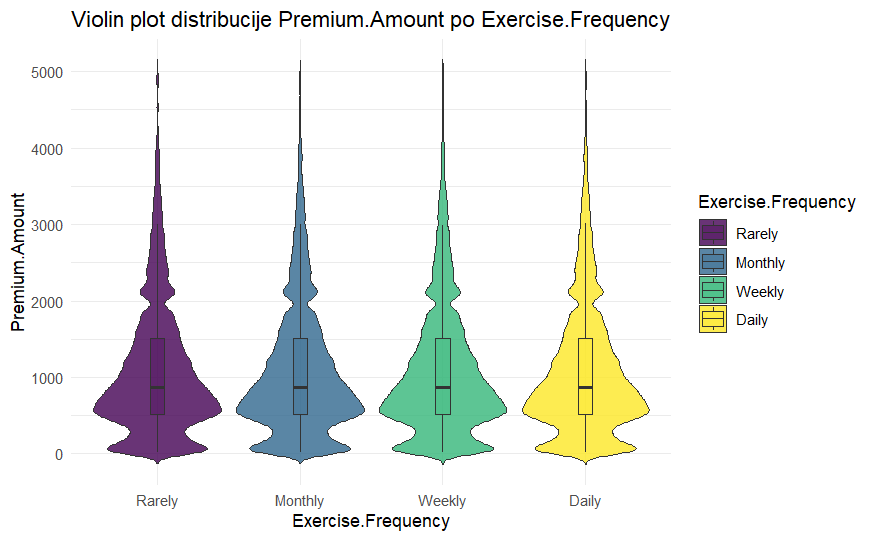

```r
ggplot(train, aes(x = Exercise.Frequency, y = Premium.Amount, fill = Exercise.Frequency)) +
  geom_violin(trim = FALSE, alpha = 0.8) +
  geom_boxplot(width = 0.1, outlier.shape = NA, alpha = 0.3) +
  labs(title = "Violin plot distribucije Premium.Amount po Exercise.Frequency", x = "Exercise.Frequency", y = "Premium.Amount") +
  theme_minimal()
```

Statisticka analiza zavisnosti varijabli

```r
set.seed(123)
categories <- unique(train$Exercise.Frequency)
categories <- categories[!is.na(categories)]

shapiro_boot <- function(cat) {
  values <- na.omit(train$Premium.Amount[train$Exercise.Frequency == cat])

  if (length(values) > 3) {
    p_values <- replicate(500, shapiro.test(sample(values, min(3000, length(values))))$p.value)
    p_mean <- mean(p_values)

    if (p_mean > 0.05) {
      sprintf("Varijabla Premium.Amount po %s kategoriji ima normalnu raspodelu.", as.character(cat))
    } else {
      sprintf("Varijabla Premium.Amount po %s kategoriji nema normalnu raspodelu.", as.character(cat))
    }
  }
  else {
    sprintf("Varijabla Premium.Amount po %s kategoriji ima manje od 3 observacije.", as.character(cat))
  }
}

lapply(categories, shapiro_boot)
```

```
[[1]]
[1] "Varijabla Premium.Amount po Weekly kategoriji nema normalnu raspodelu."

[[2]]
[1] "Varijabla Premium.Amount po Monthly kategoriji nema normalnu raspodelu."

[[3]]
[1] "Varijabla Premium.Amount po Daily kategoriji nema normalnu raspodelu."

[[4]]
[1] "Varijabla Premium.Amount po Rarely kategoriji nema normalnu raspodelu."
```

Kruskal-Wallis test radi statisticke provere distribucije po kategorijama

```r
p_value <- kruskal_test(Premium.Amount ~ Exercise.Frequency, data = train)$p

if (p_value > 0.05) {
  print("Nema statisticke razlike izmedju distribucija Premium.Amount po kategorijama Exercise.Frequency atributa.")
} else {
  print("Postoji statisticka razlika izmedju distribucija Premium.Amount po kategorijama Exercise.Frequency atributa.")
}
```

```
[1] "Nema statisticke razlike izmedju distribucija Premium.Amount po kategorijama Exercise.Frequency atributa."
```

### Distribucija varijable Premium Amount u odnosu na Property.Type

Osnovni opis varijabli

```r
df_summary_feature <- train %>%
  group_by(Property.Type) %>%
  summarise(
    Count = n(),
    Mean_Premium_Amount = mean(Premium.Amount, na.rm = TRUE),
    Median_Premium_Amount = median(Premium.Amount, na.rm = TRUE),
    Std_Premium_Amount = sd(Premium.Amount, na.rm = TRUE),
    IQR_Premium_Amount = IQR(Premium.Amount, na.rm = TRUE)
  ) %>%
  arrange(desc(Mean_Premium_Amount))

print(df_summary_feature)
```

| Property.Type | Count | Mean_Premium_Amount | Median_Premium_Amount | Std_Premium_Amount | IQR_Premium_Amount |
| --- | --- | --- | --- | --- | --- |
| Apartment | 399978 | 1104.151 | 872 | 866.9785 | 998 |
| Condo | 399673 | 1101.923 | 871 | 865.9562 | 999 |
| House | 400349 | 1101.562 | 873 | 862.0574 | 991 |

Graficka reprezentacija varijabli

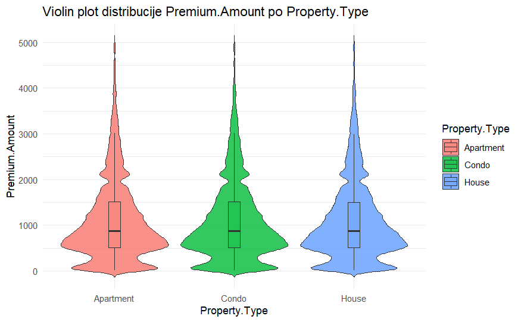

```r
ggplot(train, aes(x = Property.Type, y = Premium.Amount, fill = Property.Type)) +
  geom_violin(trim = FALSE, alpha = 0.8) +
  geom_boxplot(width = 0.1, outlier.shape = NA, alpha = 0.3) +
  labs(title = "Violin plot distribucije Premium.Amount po Property.Type", x = "Property.Type", y = "Premium.Amount") +
  theme_minimal()
```

Statisticka analiza zavisnosti varijabli

```r
set.seed(123)
categories <- unique(train$Property.Type)
categories <- categories[!is.na(categories)]

shapiro_boot <- function(cat) {
  values <- na.omit(train$Premium.Amount[train$Property.Type == cat])

  if (length(values) > 3) {
    p_values <- replicate(500, shapiro.test(sample(values, min(3000, length(values))))$p.value)
    p_mean <- mean(p_values)

    if (p_mean > 0.05) {
      sprintf("Varijabla Premium.Amount po %s kategoriji ima normalnu raspodelu.", as.character(cat))
    } else {
      sprintf("Varijabla Premium.Amount po %s kategoriji nema normalnu raspodelu.", as.character(cat))
    }
  }
  else {
    sprintf("Varijabla Premium.Amount po %s kategoriji ima manje od 3 observacije.", as.character(cat))
  }
}

lapply(categories, shapiro_boot)
```

```
[[1]]
[1] "Varijabla Premium.Amount po House kategoriji nema normalnu raspodelu."

[[2]]
[1] "Varijabla Premium.Amount po Apartment kategoriji nema normalnu raspodelu."

[[3]]
[1] "Varijabla Premium.Amount po Condo kategoriji nema normalnu raspodelu."
```

Kruskal-Wallis test radi statisticke provere distribucije po kategorijama

```r
p_value <- kruskal_test(Premium.Amount ~ Property.Type, data = train)$p

if (p_value > 0.05) {
  print("Nema statisticke razlike izmedju distribucija Premium.Amount po kategorijama Property.Type atributa.")
} else {
  print("Postoji statisticka razlika izmedju distribucija Premium.Amount po kategorijama Property.Type atributa.")
}
```

```
[1] "Nema statisticke razlike izmedju distribucija Premium.Amount po kategorijama Property.Type atributa."
```

### Distribucija varijable Premium Amount u odnosu na Number.of.Dependents

Osnovni opis varijabli

```r
df_summary_feature <- train %>%
  group_by(Number.of.Dependents) %>%
  summarise(
    Count = n(),
    Mean_Premium_Amount = mean(Premium.Amount, na.rm = TRUE),
    Median_Premium_Amount = median(Premium.Amount, na.rm = TRUE),
    Std_Premium_Amount = sd(Premium.Amount, na.rm = TRUE),
    IQR_Premium_Amount = IQR(Premium.Amount, na.rm = TRUE)
  ) %>%
  arrange(desc(Mean_Premium_Amount))

print(df_summary_feature)
```

| Number.of.Dependents | Count | Mean_Premium_Amount | Median_Premium_Amount | Std_Premium_Amount | IQR_Premium_Amount |
| --- | --- | --- | --- | --- | --- |
| NA | 109672 | 1126.442 | 892 | 885.1710 | 1046 |
| 2 | 215313 | 1104.236 | 872 | 863.0058 | 995 |
| 1 | 215076 | 1102.581 | 873 | 862.6066 | 988 |
| 3 | 221475 | 1100.703 | 872 | 862.5574 | 991 |
| 0 | 218124 | 1097.665 | 867 | 862.1948 | 983 |
| 4 | 220340 | 1095.644 | 862 | 864.1409 | 988 |

Graficka reprezentacija varijabli

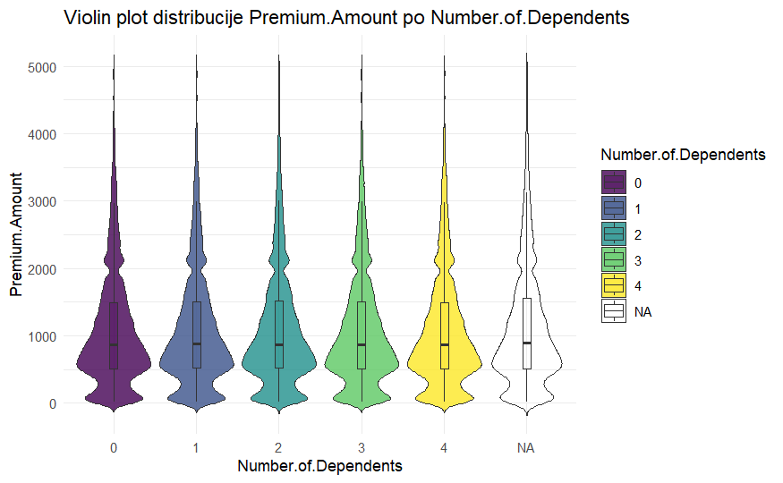

```r
ggplot(train, aes(x = Number.of.Dependents, y = Premium.Amount, fill = Number.of.Dependents)) +
  geom_violin(trim = FALSE, alpha = 0.8) +
  geom_boxplot(width = 0.1, outlier.shape = NA, alpha = 0.3) +
  labs(title = "Violin plot distribucije Premium.Amount po Number.of.Dependents", x = "Number.of.Dependents", y = "Premium.Amount") +
  theme_minimal()
```

Statisticka analiza zavisnosti varijabli

```r
set.seed(123)
categories <- unique(train$Number.of.Dependents)
categories <- categories[!is.na(categories)]

shapiro_boot <- function(cat) {
  values <- na.omit(train$Premium.Amount[train$Number.of.Dependents == cat])

  if (length(values) > 3) {
    p_values <- replicate(500, shapiro.test(sample(values, min(3000, length(values))))$p.value)
    p_mean <- mean(p_values)

    if (p_mean > 0.05) {
      sprintf("Varijabla Premium.Amount po %s kategoriji ima normalnu raspodelu.", as.character(cat))
    } else {
      sprintf("Varijabla Premium.Amount po %s kategoriji nema normalnu raspodelu.", as.character(cat))
    }
  }
  else {
    sprintf("Varijabla Premium.Amount po %s kategoriji ima manje od 3 observacije.", as.character(cat))
  }
}

lapply(categories, shapiro_boot)
```

```
[[1]]
[1] "Varijabla Premium.Amount po 1 kategoriji nema normalnu raspodelu."

[[2]]
[1] "Varijabla Premium.Amount po 3 kategoriji nema normalnu raspodelu."

[[3]]
[1] "Varijabla Premium.Amount po 2 kategoriji nema normalnu raspodelu."

[[4]]
[1] "Varijabla Premium.Amount po 0 kategoriji nema normalnu raspodelu."

[[5]]
[1] "Varijabla Premium.Amount po 4 kategoriji nema normalnu raspodelu."
```

Kruskal-Wallis test radi statisticke provere distribucije po kategorijama

```r
p_value <- kruskal_test(Premium.Amount ~ Number.of.Dependents, data = train)$p

if (p_value > 0.05) {
  print("Nema statisticke razlike izmedju distribucija Premium.Amount po kategorijama Number.of.Dependents atributa.")
} else {
  print("Postoji statisticka razlika izmedju distribucija Premium.Amount po kategorijama Number.of.Dependents atributa.")
}
```

```
[1] "Postoji statisticka razlika izmedju distribucija Premium.Amount po kategorijama Number.of.Dependents atributa."
```

Racunamo efekat Kruskal-Wallis testa kako bismo proverili:

```r
kruskal_effsize(Premium.Amount ~ Number.of.Dependents, data = train)$effsize
```

```
Kruskal-Wallis chi-squared
               1.68254e-05
```

Iako je Kruskal-Wallis test ukazao na to da postoji statisticki znacajna razlika u raspodeli Premium.Amount varijable u odnosu na nivoe Number.of.Dependents varijable, analizom vrednosti efekta, kao i uporedjivanjem medijana i IQR-a, utvrdjujemo da je ova razlika minimalna i prakticno neprimenljiva.

### Distribucija varijable Premium Amount u odnosu na Previous.Claims

Osnovni opis varijabli

```r
df_summary_feature <- train %>%
  group_by(Previous.Claims) %>%
  summarise(
    Count = n(),
    Mean_Premium_Amount = mean(Premium.Amount, na.rm = TRUE),
    Median_Premium_Amount = median(Premium.Amount, na.rm = TRUE),
    Std_Premium_Amount = sd(Premium.Amount, na.rm = TRUE),
    IQR_Premium_Amount = IQR(Premium.Amount, na.rm = TRUE)
  ) %>%
  arrange(desc(Mean_Premium_Amount))

print(df_summary_feature)
```

| Previous.Claims | Count | Mean_Premium_Amount | Median_Premium_Amount | Std_Premium_Amount | IQR_Premium_Amount |
| --- | --- | --- | --- | --- | --- |
| 9 | 1 | 1614.000 | 1614.0 | NA | 0.00 |
| 7 | 58 | 1483.241 | 1205.5 | 1007.2866 | 1431.50 |
| 6 | 302 | 1334.129 | 1113.0 | 986.5172 | 1287.25 |
| 8 | 8 | 1298.000 | 1177.5 | 925.2190 | 960.00 |
| 4 | 10668 | 1242.399 | 1010.0 | 917.5353 | 1164.25 |
| 5 | 2018 | 1239.520 | 990.0 | 927.9405 | 1176.00 |
| 3 | 49011 | 1202.657 | 964.0 | 903.1739 | 1096.00 |
| 2 | 167661 | 1172.248 | 930.0 | 891.5213 | 1065.00 |
| 1 | 300811 | 1092.003 | 861.0 | 860.5097 | 981.00 |
| 0 | 305433 | 1083.015 | 852.0 | 857.4155 | 983.00 |

[output cut: 1 more lines]

Graficka reprezentacija varijabli

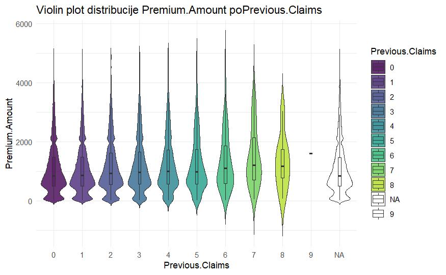

```r
ggplot(train, aes(x = Previous.Claims, y = Premium.Amount, fill = Previous.Claims)) +
  geom_violin(trim = FALSE, alpha = 0.8) +
  geom_boxplot(width = 0.1, outlier.shape = NA, alpha = 0.3) +
  labs(title = "Violin plot distribucije Premium.Amount poPrevious.Claims", x = "Previous.Claims", y = "Premium.Amount") +
  theme_minimal()
```

```r
str(train)
```

```
'data.frame':   1200000 obs. of  21 variables:
 $ id                  : int  0 1 2 3 4 5 6 7 8 9 ...
 $ Age                 : num  19 39 23 21 21 29 41 48 21 44 ...
 $ Gender              : Factor w/ 2 levels "Female","Male": 1 1 2 2 2 2 2 1 2 2 ...
 $ Annual.Income       : num  10049 31678 25602 141855 39651 ...
 $ Marital.Status      : Factor w/ 3 levels "Divorced","Married",..: 2 1 1 2 3 2 2 1 1 2 ...
 $ Number.of.Dependents: Ord.factor w/ 5 levels "0"<"1"<"2"<"3"<..: 2 4 4 3 2 2 1 3 4 3 ...
 $ Education.Level     : Ord.factor w/ 4 levels "High School"<..: 2 3 1 2 2 2 4 1 2 3 ...
 $ Occupation          : Factor w/ 3 levels "Employed","Self-Employed",..: 2 NA 2 NA 2 NA NA 1 NA 1 ...
 $ Health.Score        : num  22.6 15.6 47.2 10.9 20.4 ...
 $ Location            : Factor w/ 3 levels "Rural","Suburban",..: 3 1 2 1 1 3 1 2 3 3 ...
 $ Policy.Type         : Factor w/ 3 levels "Basic","Comprehensive",..: 3 2 3 1 3 3 1 2 3 2 ...
 $ Previous.Claims     : Ord.factor w/ 10 levels "0"<"1"<"2"<"3"<..: 3 2 2 2 1 3 3 2 2 2 ...
 $ Vehicle.Age         : num  17 12 14 0 8 4 8 11 10 9 ...
 $ Credit.Score        : num  372 694 NA 367 598 614 807 398 685 635 ...
 $ Insurance.Duration  : Ord.factor w/ 9 levels "1"<"2"<"3"<"4"<..: 5 2 3 1 4 5 6 5 8 3 ...
 $ Policy.Start.Date   : chr  "2023-12-23 15:21:39.134960" "2023-06-12 15:21:39.111551" "2023-09-30 15:21:39.221386" "2024-06-12 15:21:39.226954" ...
 $ Customer.Feedback   : Ord.factor w/ 3 levels "Poor"<"Average"<..: 1 2 3 1 1 2 1 2 2 1 ...
 $ Smoking.Status      : Factor w/ 2 levels "No","Yes": 1 2 2 2 2 1 1 1 1 1 ...
 $ Exercise.Frequency  : Ord.factor w/ 4 levels "Rarely"<"Monthly"<..: 3 2 3 4 3 3 3 1 2 4 ...
 $ Property.Type       : Factor w/ 3 levels "Apartment","Condo",..: 3 3 3 1 3 3 3 2 2 2 ...
 $ Premium.Amount      : num  2869 1483 567 765 2022 ...
```

Posto su grupe koje imaju 7-9 zahteva veoma male, grupisacemo ih u jednu kategoriju “7+” radi testiranja.

```r
train$PreviousClaimsGrouped <- as.character(train$Previous.Claims)
train$PreviousClaimsGrouped[train$PreviousClaimsGrouped %in% c("7","8","9")] <- "7+"
train$PreviousClaimsGrouped <- factor(train$PreviousClaimsGrouped,
                                      levels = c("0","1","2","3","4","5","6","7+"))

table(train$PreviousClaimsGrouped, useNA="ifany")
```

```
     0      1      2      3      4      5      6     7+   <NA>
305433 300811 167661  49011  10668   2018    302     67 364029
```

Statisticka analiza zavisnosti varijabli

```r
set.seed(123)
categories <- unique(train$PreviousClaimsGrouped)
categories <- categories[!is.na(categories)]

shapiro_boot <- function(cat) {
  values <- na.omit(train$Premium.Amount[train$PreviousClaimsGrouped == cat])

  if (length(values) > 3) {
    p_values <- replicate(500, shapiro.test(sample(values, min(3000, length(values))))$p.value)
    p_mean <- mean(p_values)

    if (p_mean > 0.05) {
      sprintf("Varijabla Premium.Amount po %s kategoriji ima normalnu raspodelu.", as.character(cat))
    } else {
      sprintf("Varijabla Premium.Amount po %s kategoriji nema normalnu raspodelu.", as.character(cat))
    }
  }
  else {
    sprintf("Varijabla Premium.Amount po %s kategoriji ima manje od 3 observacije.", as.character(cat))
  }
}

lapply(categories, shapiro_boot)
```

```
[[1]]
[1] "Varijabla Premium.Amount po 2 kategoriji nema normalnu raspodelu."

[[2]]
[1] "Varijabla Premium.Amount po 1 kategoriji nema normalnu raspodelu."

[[3]]
[1] "Varijabla Premium.Amount po 0 kategoriji nema normalnu raspodelu."

[[4]]
[1] "Varijabla Premium.Amount po 3 kategoriji nema normalnu raspodelu."

[[5]]
[1] "Varijabla Premium.Amount po 4 kategoriji nema normalnu raspodelu."

[[6]]
[1] "Varijabla Premium.Amount po 5 kategoriji nema normalnu raspodelu."

[[7]]
[1] "Varijabla Premium.Amount po 6 kategoriji nema normalnu raspodelu."

[[8]]
[1] "Varijabla Premium.Amount po 7+ kategoriji nema normalnu raspodelu."
```

Kruskal-Wallis test radi statisticke provere distribucije po kategorijama

```r
p_value <- kruskal_test(Premium.Amount ~ PreviousClaimsGrouped, data = train)$p

if (p_value > 0.05) {
  print("Nema statisticke razlike izmedju distribucija Premium.Amount po kategorijama PreviousClaimsGrouped atributa.")
} else {
  print("Postoji statisticka razlika izmedju distribucija Premium.Amount po kategorijama PreviousClaimsGrouped atributa.")
}
```

```
[1] "Postoji statisticka razlika izmedju distribucija Premium.Amount po kategorijama PreviousClaimsGrouped atributa."
```

Racunamo efekat Kruskal-Wallis testa kako bismo proverili:

```r
kruskal_effsize(Premium.Amount ~ PreviousClaimsGrouped, data = train)$effsize
```

```
Kruskal-Wallis chi-squared
               0.001827621
```

Odbacujemo kolonu PreviousClaimsGrouped

```r
train <- train %>%
  select(-PreviousClaimsGrouped)
```

Grupisanje nivoa sa 7, 8 i 9 zahteva dalo je jasniju sliku trenda koji postoji izmedju Previous.Claims i Premium.Amount. Medijana Premium.Amount raste sa brojem prethodnih zahteva: veci broj prethodnih zahteva korelira sa visim iznosom premije. Prilikom feature engineering-a potrebno je izvrsiti grupisanje nivoa sa malim brojem zahteva.

### Distribucija varijable Premium Amount u odnosu na Insurance.Duration

Osnovni opis varijabli

```r
df_summary_feature <- train %>%
  group_by(Insurance.Duration) %>%
  summarise(
    Count = n(),
    Mean_Premium_Amount = mean(Premium.Amount, na.rm = TRUE),
    Median_Premium_Amount = median(Premium.Amount, na.rm = TRUE),
    Std_Premium_Amount = sd(Premium.Amount, na.rm = TRUE),
    IQR_Premium_Amount = IQR(Premium.Amount, na.rm = TRUE)
  ) %>%
  arrange(desc(Mean_Premium_Amount))

print(df_summary_feature)
```

| Insurance.Duration | Count | Mean_Premium_Amount | Median_Premium_Amount | Std_Premium_Amount | IQR_Premium_Amount |
| --- | --- | --- | --- | --- | --- |
| 2 | 131160 | 1106.883 | 878 | 863.6754 | 996 |
| 7 | 133592 | 1105.965 | 877 | 866.2254 | 998 |
| 8 | 133800 | 1105.877 | 876 | 868.0096 | 1000 |
| 4 | 132182 | 1104.723 | 872 | 866.3775 | 994 |
| 6 | 132141 | 1104.558 | 873 | 866.5503 | 998 |
| 3 | 132018 | 1101.734 | 872 | 865.7912 | 988 |
| 5 | 132253 | 1100.812 | 872 | 859.9658 | 993 |
| 1 | 135072 | 1097.043 | 861 | 865.4312 | 997 |
| 9 | 137781 | 1095.677 | 861 | 862.9107 | 998 |
| NA | 1 | 1044.000 | 1044 | NA | 0 |

Graficka reprezentacija varijabli

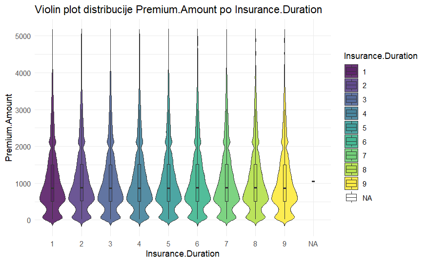

```r
ggplot(train, aes(x = Insurance.Duration, y = Premium.Amount, fill = Insurance.Duration)) +
  geom_violin(trim = FALSE, alpha = 0.8) +
  geom_boxplot(width = 0.1, outlier.shape = NA, alpha = 0.3) +
  labs(title = "Violin plot distribucije Premium.Amount po Insurance.Duration", x = "Insurance.Duration", y = "Premium.Amount") +
  theme_minimal()
```

Statisticka analiza zavisnosti varijabli

```r
set.seed(123)
categories <- unique(train$Insurance.Duration)
categories <- categories[!is.na(categories)]

shapiro_boot <- function(cat) {
  values <- na.omit(train$Premium.Amount[train$Insurance.Duration == cat])

  if (length(values) > 3) {
    p_values <- replicate(500, shapiro.test(sample(values, min(3000, length(values))))$p.value)
    p_mean <- mean(p_values)

    if (p_mean > 0.05) {
      sprintf("Varijabla Premium.Amount po %s kategoriji ima normalnu raspodelu.", as.character(cat))
    } else {
      sprintf("Varijabla Premium.Amount po %s kategoriji nema normalnu raspodelu.", as.character(cat))
    }
  }
  else {
    sprintf("Varijabla Premium.Amount po %s kategoriji ima manje od 3 observacije.", as.character(cat))
  }
}

lapply(categories, shapiro_boot)
```

```
[[1]]
[1] "Varijabla Premium.Amount po 5 kategoriji nema normalnu raspodelu."

[[2]]
[1] "Varijabla Premium.Amount po 2 kategoriji nema normalnu raspodelu."

[[3]]
[1] "Varijabla Premium.Amount po 3 kategoriji nema normalnu raspodelu."

[[4]]
[1] "Varijabla Premium.Amount po 1 kategoriji nema normalnu raspodelu."

[[5]]
[1] "Varijabla Premium.Amount po 4 kategoriji nema normalnu raspodelu."

[[6]]
[1] "Varijabla Premium.Amount po 6 kategoriji nema normalnu raspodelu."

[[7]]
[1] "Varijabla Premium.Amount po 8 kategoriji nema normalnu raspodelu."

[[8]]
[1] "Varijabla Premium.Amount po 9 kategoriji nema normalnu raspodelu."

[[9]]
[1] "Varijabla Premium.Amount po 7 kategoriji nema normalnu raspodelu."
```

Kruskal-Wallis test radi statisticke provere distribucije po kategorijama

```r
p_value <- kruskal_test(Premium.Amount ~ Insurance.Duration, data = train)$p

if (p_value > 0.05) {
  print("Nema statisticke razlike izmedju distribucija Premium.Amount po kategorijama Insurance.Duration atributa.")
} else {
  print("Postoji statisticka razlika izmedju distribucija Premium.Amount po kategorijama Insurance.Duration atributa.")
}
```

```
[1] "Postoji statisticka razlika izmedju distribucija Premium.Amount po kategorijama Insurance.Duration atributa."
```

Racunamo efekat Kruskal-Wallis testa kako bismo proverili:

```r
kruskal_effsize(Premium.Amount ~ Insurance.Duration, data = train)$effsize
```

```
Kruskal-Wallis chi-squared
              2.196023e-05
```

Iako je Kruskal-Wallis test ukazao na to da postoji statisticki znacajna razlika u raspodeli Premium.Amount varijable u odnosu na nivoe Insurance.Duration varijable, analizom vrednosti efekta, kao i uporedjivanjem medijana i IQR-a, utvrdjujemo da je ova razlika minimalna i prakticno neprimenljiva.

## Zakljucak

- Prema Shapiro-Wilk testu, Premium.Amount u vecini grupa po kategorijama ne prati normalnu raspodelu. Iz tog razloga, koristimo Kruskal-Wallis test ili Mann-Whitney U test.
- Atributi koji nemaju znacajnu vezu sa ciljnom varijablom: Gender, Marital.Status, Education.Level, Location, Policy.Type, Smoking.Status, Exercise.Frequency, Property.Type, Customer.Feedback.
- Iako Kruskal-Wallis test ukazuje na znacajnu statisticku razliku distribucije Premium.Amount varijable u odnosu na kategorije Occupation, Insurance.Duration i Number.of.Dependents varijabli, daljom analizom je utvrdjeno da je ova razlika minimalna i prakticno neprimenljiva.
- Na raspodelu Premium.Amount promenljive utice broj prethodno kreiranih zahteva, Previous.Claims. Premija se povecava sa povecanjem broja kreiranih zahteva.